# Brève analyse des financements versés aux chaînes YouTube via la plateforme Tipeee

réalisée le 16 avril 2019

par Robin Lamarche-Perrin : Robin.Lamarche-Perrin@lip6.fr

avec l’aide de Manon Bril : https://www.youtube.com/channel/UCKjDY4joMPcoRMmd-G1yz1Q

Cette note de recherche fait suite à une série de vidéos publiées par Stéphane Édouard sur YouTube en octobre 2018 :

- https://www.youtube.com/watch?v=j-mL6euUSA8
- https://www.youtube.com/watch?v=lfCS7_n0S-g
- https://www.youtube.com/watch?v=ynj-RexH644

Ces vidéos proposent de courtes analyses de sociologie quantitative (*sic*) portant sur la rémunération de vidéastes sur YouTube via Tipeee, une plateforme de financement participatif (https://fr.tipeee.com/). Elles cherchent notamment à montrer que les femmes sont mieux rémunérées que les hommes sur cette plateforme. De nombreuses approximations dans la manière de traiter les données, ainsi que des hypothèses statistiques fallacieuses, nous ont poussées à réaliser des expériences complémentaires pour vérifier les résultats qui y étaient exposés.

Cette note est un exercice préliminaire, qui pourrait donner suite à un éventuel travail de recherche plus approfondi, mais qui cherche déjà à montrer que les choses sont plus complexes que ce que prétend Stéphane Édouard dans ses vidéos. En particulier, pour réaliser l’analyse qu’il propose, son hypothèse de travail présuppose que les financements Tipeee de deux chaînes YouTube peuvent être comparés lorsqu’ils sont rapportés à leur nombre d’abonnements. L’expérience qui suit montre que cette hypothèse n’est pas valide lorsque l’on regarde un jeu de données un tant soit peu conséquent.

### Données

Notre corpus regroupe l’ensemble des comptes Tipeee :

- associés à une chaîne YouTube,
- comptant au moins 100 donateurs ou donatrices différentes,
- et dont la somme des dons mensuels a été rendue publique sur la plateforme.

Les donées ont été recueillies le 14 avril 2019. Elles regroupent les statistiques de 83 comptes Tipeee, croisées avec les statistiques fournies par le site Social Blade (https://socialblade.com/) concernant les chaînes YouTube associées. Nous les rendons disponibles ici pour celles et ceux qui souhaiteraient compléter ou poursuivre ces investigations : https://www-complexnetworks.lip6.fr/~lamarche/tipeee/tipeee-statistics.csv

Listes des variables disponibles :

- `tipeee_account` : nom du compte tipeee
- `youtube_channel` : nom de la chaîne YouTube associée
- `country` : pays référencé par la chaîne
- `gender` : genre de la personne ayant créé la chaîne (*cf.* détails ci-dessous)
- `date` : date de création de la chaîne
- `tipeee_type1`, `tipeee_type2` et `youtube_type3` : catégorisation de la chaîne suivant différentes typologies (deux référencées sur Tipeee et une sur YouTube)
- `videos` : nombre de vidéos publiées sur la chaîne
- `viewers` : nombre d’abonnements de la chaîne
- `views` : nombre total de vues réalisées par les vidéos publiées
- `tippers` : nombre de financeurs sur Tipeee
- `tips` : montant total des dons mensuels sur Tipeee

La variable `gender` a été encodée manuellement. Elle désigne le genre de la personne ayant créé la chaîne ou étant majoritairement responsable de son contenu : `M` pour masculin, `F` pour féminin, et `N` dans le cas où le genre n’est pas identifiable (8 cas sur 83 correspondant à des collectifs mixtes de créateurices).

### Analyse

Nous utilisons le langage de programmation `R` pour l’analyse statistique de ces données, ainsi que la librairie `ggplot2` pour la visualisation des résultats.

```r
library (ggplot2)
library (ggrepel)
library (scales)
set.seed (42)
```

Chargement des données :

```r
data <- read.csv ("tipeee-statistics.csv")
```

#### Une hypothèse fallacieuse : la règle de trois pour comparer les chaînes YouTube

Un premier réflexe pour comparer les revenus de deux chaînes YouTube est de rapporter ces revenus à leur nombre d’abonnements. En effet, on ne s’attend pas à ce qu’une chaîne de 1 581 283 abonné·e·s (*LinksTheSun*) engendre la même quantité de dons qu’une chaîne de 9 689 abonné·e·s (*Vive L’Europe !*). La quantité de don par abonnement semble donc être un bon indicateur normalisé pour quantifier le revenu des chaînes et pour ainsi les comparer. Il s’agit de la fameuse “règle de trois” qui constitue le cœur de la démarche proposée par Stéphane Édouard dans ses vidéos (https://www.youtube.com/watch?v=j-mL6euUSA8&t=6m02s).

Nous commençons donc par visualiser l’ensemble des 83 chaînes retenues en fonction de leur nombre d’abonnements et de leur don mensuel moyen par abonnement. (Veuillez noter l’utilisation d’une double échelle logarithmique pour mieux distinguer la distribution des variables qui couvre une large échelle de valeurs.)

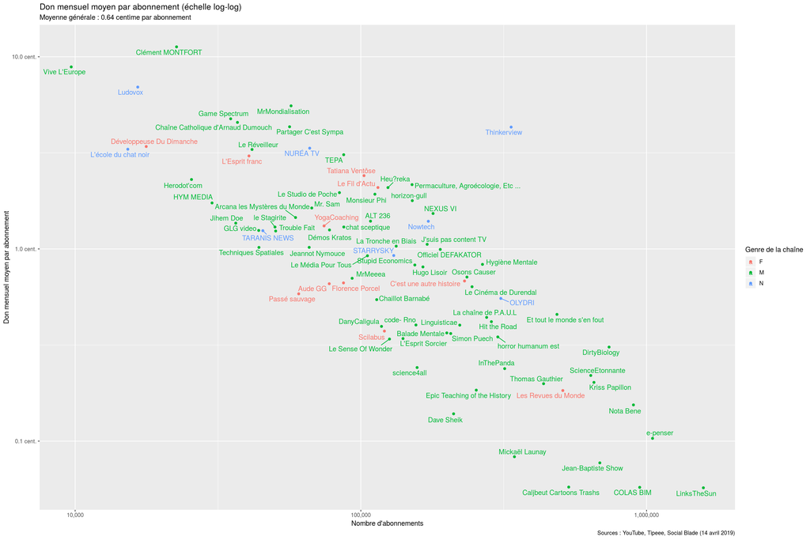

```r
ggplot (data, aes (x = viewers, y = tips/viewers, label = youtube_channel)) +
    geom_point (aes (color = gender)) + geom_text_repel (aes (color = gender)) +
    scale_x_log10 (labels = comma) +
    scale_y_log10 (labels = dollar_format (accuracy = 0.1, scale = 100, suffix = " cent.", prefix = ""))
```

Il apparaît de manière évidente que les dons mensuels moyens dépendent fortement du nombre d’abonnements : plus on a d’abonné·e·s, moins on a de don par abonné·e. Cette tendance semble s’appliquer de manière homogène à toutes les chaînes du corpus, indépendamment de considérations thématiques ou genrées, comme en témoigne la distribution diagonale et relativement étroite dans le graphique ci-dessus.

Plusieurs hypothèses en psychologie sociale pourraient être avancées pour tenter d’expliquer ce phénomène. En particulier, (1) la volonté de financer en priorité des chaînes qui débutent ou des chaînes moins connues que les autres et (2) la possible différence qui existe entre une petite communauté d’abonné·e·s (facile à mobiliser en termes de financement) et une large communauté (dont une majorité d’abonné·e·s n’aurait pas la volonté ou les moyens de participer au financement).

Quoi qu’il en soit, il est important de prendre en compte cet effet lors de la comparaison de deux chaînes YouTube : même normalisés, on ne devrait pas s’attendre à avoir des dons équivalents pour des chaînes ayant des nombres d’abonnements très différents. Notez que la dépendance mise en évidence, qui apparaît linéaire dans le graphique ci-dessus, met en relation les deux variables exprimées sur des échelles logarithmiques. On a donc une formule du type `log10 (tips / viewers) = a + b * log10 (viewers)`.

#### Rectifier le tir : un modèle linéaire pour expliquer la variance observée

Afin de caractériser l’effet décrit ci-dessus, nous procédons à une regression linéaire entre les deux variables observées (don par abonnement et nombre d’abonnements). L’objectif est d’ainsi proposer un premier modèle statistique simple pour rendre compte de la première cause de variabilité des observations : la dépendance des dons au nombre d’abonnements.

```r
reg <- lm (log10 (tips/viewers) ~ log10 (viewers), data)
summary (reg)
```

```
##
## Call:
## lm(formula = log10(tips/viewers) ~ log10(viewers), data = data)
##
## Residuals:
##      Min       1Q   Median       3Q      Max
## -0.59595 -0.23004 -0.01454  0.21567  1.10866
##
## Coefficients:
##                Estimate Std. Error t value Pr(>|t|)
## (Intercept)     2.68007    0.37584   7.131 3.77e-10 ***
## log10(viewers) -0.93278    0.07327 -12.730  < 2e-16 ***
## ---
## Signif. codes:  0 '***' 0.001 '**' 0.01 '*' 0.05 '.' 0.1 ' ' 1
##
## Residual standard error: 0.3038 on 81 degrees of freedom
## Multiple R-squared:  0.6667, Adjusted R-squared:  0.6626
## F-statistic: 162.1 on 1 and 81 DF,  p-value: < 2.2e-16
```

Les résultats de la regression nous indiquent que le nombre d’abonnements explique en effet de manière très significative le don moyen par abonnement (*p-value* inférieure à 0,001). En particulier, 66% des variations observées dans les données peuvent être expliquées par cette variable. Ainsi, lors des comparaisons réalisées par Stéphane Édouard dans ses vidéos, une grande partie des écarts qu’il observe peuvent être directement expliqués par les effets décrits ci-dessus.

Nous pouvons maintenant intégrer la relation découverte à la figure précédente pour mettre en évidence les *résidus*, c’est-à-dire les variations qui restent inexpliquées et qui pourront éventuellement être corrélées aux autres variables qui nous intéressent (thématiques abordées, genre de la chaîne, date de création, *etc.*). Ces résidus sont représentés dans le graphique ci-dessous par la distance entre les observations et la droite diagonale déterminée par la regression linéaire.

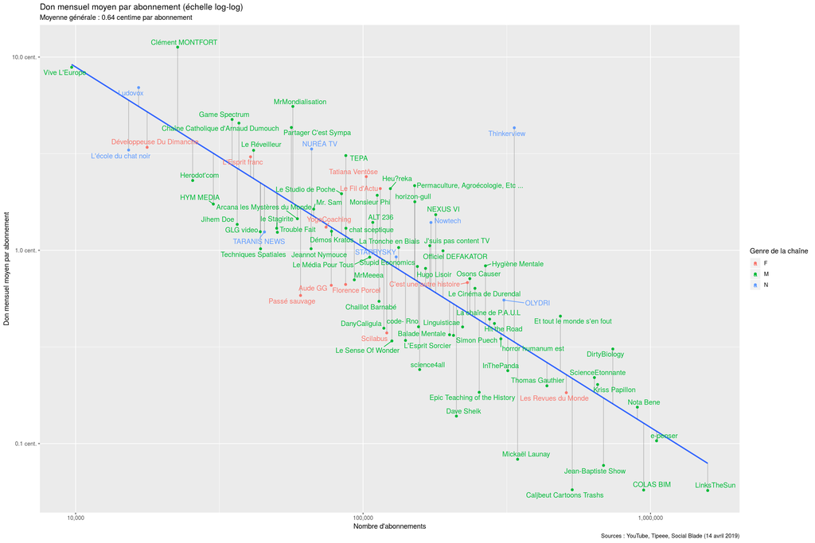

```r
ggplot (data, aes (x = viewers, y = tips/viewers, label = youtube_channel)) +
    geom_smooth (method = lm, se = FALSE, alpha = 0.2) +
    geom_segment (aes (xend = viewers, yend = 10^predict(reg)), alpha = 0.2) +
    geom_point (aes (color = gender)) + geom_text_repel (aes (color = gender)) +
    scale_x_log10 (labels = comma) +
    scale_y_log10 (labels = dollar_format (accuracy = 0.1, scale = 100, suffix = " cent.", prefix = ""))
```

#### Continuer sur de bonnes bases : est-ce que le genre explique les variations observées ?

Reste à savoir à quoi sont dues les 34% de variation qui ne sont pas expliqués par notre modèle linéaire, c’est-à-dire les distances observées dans le graphique ci-dessus entre la droite diagonale et les observations.

En particulier, la question posée par Stéphane Édouard peut être ainsi reformulée : est-ce que les écarts observés dans les dons mensuels moyens *sachant le nombre d’abonnements* peuvent être expliqués par le genre de la personne responsable du contenu de la chaîne YouTube ? En d’autres termes, est-ce que les chaînes créées par des femmes sont plutôt en-dessous de la diagonale (peu de dons sachant le nombre d’abonnements) ou plutôt au-dessus de la diagonale (beaucoup de dons sachant le nombre d’abonnements) ?

Pour répondre à cette question, nous intégrons la variable catégorielle `gender` à la regression linéaire, en retirant préalablement du corpus les 8 chaînes dont le genre n’a pas été identifié (*cf.* plus haut).

```r
data2 <- data [data$gender != "N", ]
data2$gender <- factor (data2$gender, levels = c("M", "F"))
reg <- lm (log10 (tips/viewers) ~ log10 (viewers) + gender, data2)
summary (reg)
```

```
##
## Call:
## lm(formula = log10(tips/viewers) ~ log10(viewers) + gender, data = data2)
##
## Residuals:
##      Min       1Q   Median       3Q      Max
## -0.56028 -0.21687  0.00813  0.21414  0.50196
##
## Coefficients:
##                Estimate Std. Error t value Pr(>|t|)
## (Intercept)     2.94567    0.38408   7.669 6.34e-11 ***
## log10(viewers) -0.98718    0.07412 -13.319  < 2e-16 ***
## genderF        -0.05660    0.09333  -0.606    0.546
## ---
## Signif. codes:  0 '***' 0.001 '**' 0.01 '*' 0.05 '.' 0.1 ' ' 1
##
## Residual standard error: 0.2823 on 72 degrees of freedom
## Multiple R-squared:  0.714,  Adjusted R-squared:  0.706
## F-statistic: 89.86 on 2 and 72 DF,  p-value: < 2.2e-16
```

Cette seconde regression nous indique que la variable de genre ne permet pas d’expliquer les variations restantes, ni dans un sens, ni dans l’autre. La variable est même extrêmement peu significative (*p-value* supérieure à 0,50). Ainsi, si l’on considère les dons mensuels moyens comme un marqueur de revenu, et en considérant un simple modèle linéaire pour comparer les dons associés à deux chaînes YouTube différentes, il est impossible de dire avec ces données que les femmes gagnent plus ou moins que les hommes sur Tipeee.

Notez que le raisonnement est toujours valide lorsque l’on considère les dons mensuels moyens rapportés au nombre de donateurices sur Tipeee. La variable de genre est même encore moins significative (*p-value* supérieure à 0,81).

```r
reg <- lm (log10 (tips/tippers) ~ log10 (tippers) + gender, data2)
summary (reg)
```

```
##
## Call:
## lm(formula = log10(tips/tippers) ~ log10(tippers) + gender, data = data2)
##
## Residuals:
##      Min       1Q   Median       3Q      Max
## -0.39176 -0.12014 -0.00940  0.08071  0.61848
##
## Coefficients:
##                Estimate Std. Error t value Pr(>|t|)
## (Intercept)     1.17187    0.18855   6.215 2.98e-08 ***
## log10(tippers) -0.23470    0.07784  -3.015  0.00354 **
## genderF         0.01458    0.06068   0.240  0.81078
## ---
## Signif. codes:  0 '***' 0.001 '**' 0.01 '*' 0.05 '.' 0.1 ' ' 1
##
## Residual standard error: 0.1845 on 72 degrees of freedom
## Multiple R-squared:  0.1163, Adjusted R-squared:  0.09173
## F-statistic: 4.737 on 2 and 72 DF,  p-value: 0.01168
```

### Pour aller plus loin

Voici d’autres expériences préliminaires réalisées avec ces données. Nous nous contentons ici d’une analyse purement descriptive des résultats et laissons le soin de fournir des explications sociologiques à de futures recherches sur le sujet.

#### Statistiques fournies par YouTube

Dans ce premier graphique, nous visualisons l’ensemble des 83 chaînes en fonction du nombre de vidéos qu’elles ont publiées et du nombre de vues moyen par vidéo.

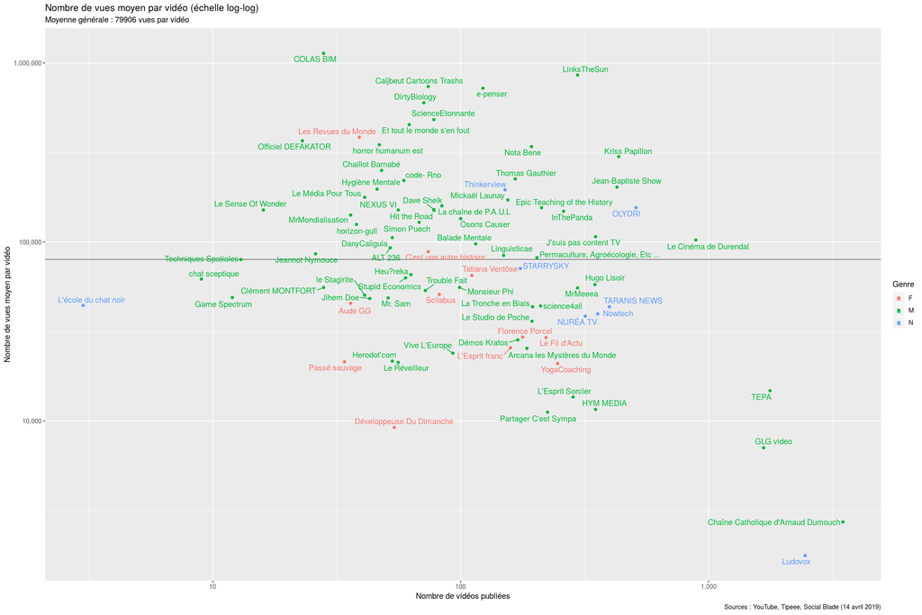

```r
ggplot (data, aes (x = videos, y = views/videos, label = youtube_channel)) +
    geom_hline (yintercept = sum (data$views) / sum (data$videos), alpha = 0.5) +
    geom_point (aes (color = gender)) + geom_text_repel (aes (color = gender)) +
    scale_x_log10 (labels = comma) + scale_y_log10 (labels = comma)
```

On observe, à une ou deux exceptions près, que les vidéos réalisées par des femmes font en moyenne moins de vues que les autres. Cette première observation mériterait déjà une analyse plus détaillée visant à en identifier d’éventuelles variables cachées. Comme de nombreux facteurs peuvent contribuer à l’audience d’une chaîne, et aussi bien des facteurs quantitatifs (*e.g.*, date de création, fréquence des publications, durée des vidéos) que des facteurs qualitatifs (*e.g.*, thématiques abordées, qualité du contenu, méthodes de communication), nous laissons le soin à la sociologie des médias de s’emparer du sujet. (À nouveau, cette note se contente d’une analyse statistique exploratoire et descriptive.)

#### Statistiques fournies par Tipeee

Nous proposons deux métriques pour une première analyse des donations sur Tipeee :

- Le pourcentage de donateurices parmi les abonné·e·s : sur 100 abonnements, combien de personnes vont sur Tipeee pour faire un don ?
- Le don mensuel moyen par donateurice : une fois arrivée sur Tipeee, combien cette personne donne en moyenne ?

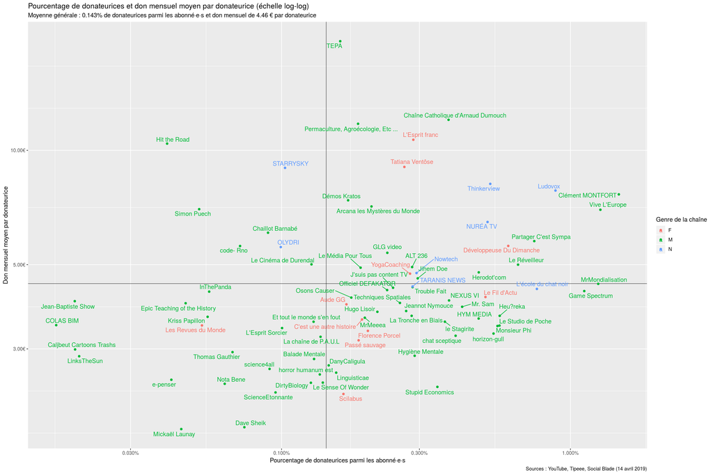

```r
ggplot (data, aes (x = tippers/viewers, y = tips/tippers, label = youtube_channel)) +
    geom_vline (xintercept = sum (data$tippers) / sum (data$viewers), alpha = 0.5) +
    geom_hline (yintercept = sum (data$tips) / sum (data$tippers), alpha = 0.5) +
    geom_point (aes (color = gender)) + geom_text_repel (aes (color = gender)) +
    scale_x_log10 (labels = percent) + scale_y_log10 (labels = dollar_format (suffix = "€", prefix = ""))
```

Interprétation du graphique :

- À droite : les chaînes YouTube pour lesquelles la plus grande proportion des abonné·e·s YouTube font des dons sur Tipeee. De nombreux facteurs peuvent expliquer cette première métrique, à commencer par la capacité de la chaîne a mobiliser ses abonné·e·s en termes de financement (méthodes de communication).
- En haut : les chaînes YouTube qui reçoivent les dons les plus important par donateurice. Ici, une étude socio-démographique de l’audience des différentes chaînes est évidemment primordiale pour tenter d’expliquer la hauteur de ces dons.

Nous remarquons que les chaînes créées par des femmes se situent en majorité dans la partie droite du graphique, signifiant qu’elles parviennent à mieux mobiliser leurs abonné·e·s que la moyenne. En revanche, aucune différenciation évidente n’apparaît dans ce graphique quant à la seconde métrique.